# Gestión del presupuesto semanal de los estudiantes UTEC del ciclo 2023-1

Análisis de gasto, ahorro y presupuesto semanal

31 Agosto, 2023

# 1 Introduccion

## 1.1 Contexto

El ahorro es una necesidad en la planificación financiera de todos los individuos y los hogares. También es relevante para los estudiantes universitarios para tener recursos que les permitan atender necesidades asociadas con la educación, como son textos escolares, materiales, transporte y alimentación y tener recursos para la diversión y el entretenimiento.En particular la conducta económica de los estudiantes universitarios está determinada por el ingreso que perciben, el cual se espera que provenga principalmente de sus padres y familiares dado que la universidad es de carácter privado. Esto podría explicar los hábitos de administración financiera, la importancia que le dan los alumnos a sus gastos, así como los hábitos del ahorro.(Reus, Arroyare & Bedoya, 2007)

## 1.2 Relevancia

La gestión del presupuesto personal es fundamental para la estabilidad financiera y decisiones acertadas sobre gastos y ahorros de los estudiantes de la UTEC. Evaluar la gestión de su presupuesto semanal permitirá identificar áreas de mejora y brindarles herramientas para desarrollar hábitos financieros, que serán útiles en su carrera y vida profesional. En la UTEC, es común que los estudiantes realicen proyectos grupales con presupuestos limitados, esto simula situaciones reales que enfrentarán en su vida laboral. Una formación económica temprana, evita dificultades para gestionar recursos asignados en proyectos más grandes. Una buena gestión del presupuesto personal implica equilibrar ingresos, gastos, establecer prioridades y ahorrar. Estas habilidades son transferibles a proyectos grupales, donde decisiones financieras acertadas marcan la diferencia. En conclusión, evaluar la gestión del presupuesto semanal de los estudiantes de la UTEC es relevante con su formación y carrera. Desarrollar hábitos financieros tempranos beneficiará su bienestar económico, personal y los prepara para enfrentar proyectos grupales en ciclos superiores y vida laboral. La eficiente gestión de recursos es clave para el éxito.

## 1.3 Objetivos:

> Objetivo general: Evaluar el conocimiento y la aplicación de la gestión financiera en los estudiantes matriculados en la UTEC durante el ciclo 2023-1.

Como *objetivos específicos* del presente proyecto, se tienen los siguientes:

- Determinar si los estudiantes matriculados en la UTEC durante el ciclo 2023-1 tienen conocimientos sobre Gestión financiera.
- Evaluar si se están aplicando los conocimientos de gestión financiera a través del análisis de la cantidad típica de gastos semanales.
- Analizar el presupuesto semanal de los estudiantes de la UTEC según su escala de pago asignada y si este se relaciona con respecto a los ahorros que se obtienen semanalmente.

## 1.4 Instalacion de paquetes

Si hay problemas con la instalación, consultar el siguiente enlace.[Enlacedeayuda](https://rpubs.com/dafealos/645524)

```r
library(remotes)
remotes::install_github("giocomai/ganttrify")
```

[output not shown]

[output not shown]

[output not shown]

```
##
##  C:\tmp1\RtmpiYkG77\downloaded_packages
```

[output not shown]

```
## -- R CMD build -----------------------------------------------------------------
```

[output not shown]

[output not shown]

```r
library(ganttrify)
```

```r
library(psych)
library(dplyr)
library(readr)
library(DescTools)
library(car)
library(readr)
library(tidyr)
```

```r
library(ggplot2)
library(remotes)
library(ganttrify)
```

## 1.5 Planificacion

Para manejar la distribución de nuestro proyecto entre todos, elaboramos un Diagrama de Gantt

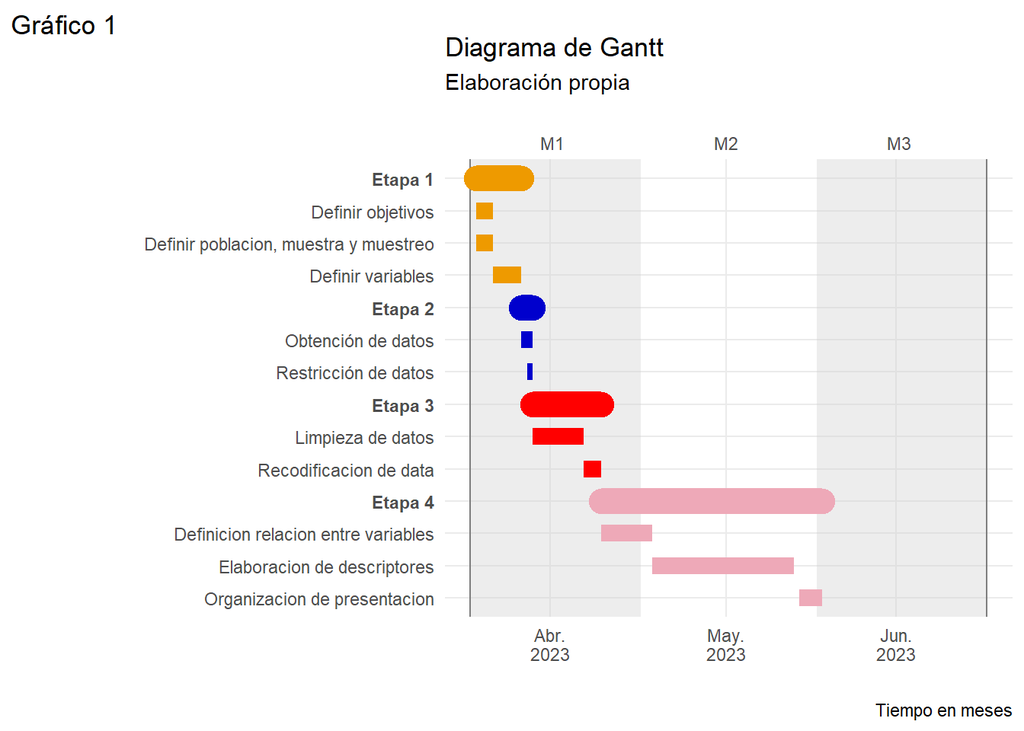

# 2 Datos

## 2.1 Proceso de recolección de datos

Trabajamos con datos de una encuesta importante sobre la realidad de los estudiantes de esta universidad. Analizamos gráficamente la dependencia económica de los estudiantes que estudian y los que estudian y trabajan. Se determinaron variables y se elaboraron preguntas para recopilar respuestas. Revisamos en grupo las restricciones a las variables y mejoramos la claridad de algunas preguntas.

## 2.2 Enlace a encuesta

Para acceder a la encuesta, acceda al siguiente enlace [Encuesta](https://docs.google.com/forms/d/e/1FAIpQLSeitnsLrSGw2S-478NG1Lmlbsfi4r9biMMMKFnfgNkvhMqmfg/viewform)

## 2.3 Población, muestra y muestreo

La población de estudio es la comunidad de UTEC y la unidad muestral son los estudiantes matriculados en el 2023-01. El tamaño de la muestra es de 170 observaciones. El tipo de muestreo es aleatorio simple (MAS) ya que nuestra muestra será escogida al azar. La representatividad consta de estudiantes de diferentes ciclos de UTEC y algunos que también trabajan, lo que nos permitirá realizar un análisis representativo.

## 2.4 Variables

- Variables de estudio

  - | Variable | Tipo1 | Tipo2 | Restricción |
    | --- | --- | --- | --- |
    | Ingreso a la Universidad | Categórica | Ordinal | Entre los ciclos 18-1 y 23-1 |
    | Estudia y Trabaja | Categórica | Nominal | Opciones: Si,No |
    | Escala | Categórica | Nominal | Opciones: A,B,C,D,E |
    | Beca | Categórica | Nominal | Ninguna |
    | Presupuesto Semanal | Numérica | Discreta | Valores enteros |
    | Cantidad de Almuerzos | Numérica | Discreta | Número entre 0 y 6 |
    | Precio máximo de almuerzos | Numérica | Continua | Numero decimal entre 5 y 30 |
    | Tipo de Transporte | Categórica | Nominal | Opciones: Metropolitano o tren, carro particular, taxi, otros |
    | Gasto Semanal en Transporte | Numérica | Continua | Número decimal entre 1 y 100 |
    | Plan Móvil | Categórica | Nominal | “Soy pospago” o “soy prepago” |
    | Asistencia a la Universidad | Numérica | Discreta | Entero menor que 7 |
    | Gasto Extra | Categórica | Nominal | Valores menores a 500 |
    | Planificación de gasto Semanal | Categórica | Nominal | Opciones: Si,No |
    | Conocimiento Financiero | Categórica | Nominal | 4 categorías |
    | Frecuencia de Aprendizaje | Categórica | Ordinal | 5 niveles |
    | Medio de Información | Categórica | Nominal | 6 categorías |
    | Ahorro Semanal | Numérica | Continua | Numero entero |
    | Organización | Numérica | Discreta | 5 niveles |
    | Nivel de Administración | Categórica | Nominal | 4 niveles |
    | Cantidad de Talleres | Numérica | Discreta | Opciones de texto largo (5 en total) |
    | Satisfacción del presupuesto Semanal | Categórica | Ordinal | 4 niveles |
    | Gasto Cubierto | Numérica | Discreta | Valor entero menor a 5 |
    | Eficiencia de Planificación | Categórica | Nominal | 4 niveles |
    | Gasto Plan Móvil | Numérica | Discreta | Valores menores a 100 |

# 3 Limpieza base de datos

Leemos nuestra base de datos.

```r
BD <- read_csv('GyP semanal.csv')
```

```
## -------------------------------------------------------- Delimiter: "," chr
## (17): Marca temporal, Dirección de correo electrónico, ¿Cuál es tu año d... dbl
## (9): ¿De cuánto es tu presupuesto semanal en soles? Ingresar un número ... lgl
## (9): ¿Cuentas con un crédito educativo? Si no cuenta con crédito, selec...
```

## 3.1 Eliminar columnas inservibles

```r
BD %>%  dplyr::select(-1,-2,-7,-9,-22,-24,-31,-32,-33,-34,-35) -> BD
```

Con la funcion select quitamos las columnas inservibles. ## Renombramos variables Utilizamos la funcion names.

```r
names(BD)
```

```
##  [1] "¿Cuál es tu año de ingreso a la universidad?"
##  [2] "¿Estudias y trabajas al mismo tiempo?"
##  [3] "¿A qué escala de crédito perteneces?"
##  [4] "¿Eres becado? ¿Cuentas con un crédito educativo?, si es así selecciona el valor de tu porcentaje."
##  [5] "¿De cuánto es tu presupuesto semanal en soles? Ingresar un número sin símbolos. Si es decimal, usar el punto (.)"
##  [6] "¿Cuántas veces a la semana compras almuerzo en la UTEC o cerca a la UTEC?"
##  [7] "Si compras almuerzo, ingresa el monto máximo que pagas por uno."
##  [8] "¿Cómo te transportas a la universidad? Si usas Metropolitano o tren además de bus, selecciona la primera opción."
##  [9] "¿Cuánto gastas a la semana en transporte?\nEn caso, vayas en carro particular ingresa el monto que gastas en combustible a la semana."
## [10] "¿Tienes línea celular postpago o prepago?"
## [11] "¿Cuántas veces a la semana asistes presencialmente a la UTEC?"
## [12] "¿A parte de los gastos básicos que haces, semanalmente, que tanto sueles gastar adicionalmente el monto restante o prefieres ahorrarte ese monto ?"
## [13] "¿Realizas una planificación semanal sobre tus gastos?"
## [14] "¿Tiene conocimientos de hábitos financieros?"
## [15] "¿Qué tan a menudo se informa sobre cómo mejorar sus finanzas? (Asistir a eventos, talleres o cursos, leer revistas, tik toks, etc)"
## [16] "¿Por qué medio suele informarse más acerca de cómo manejar sus finanzas?"
## [17] "¿Cuánto aproximadamente ahorra a la semana? En soles."
## [18] "Elija la opción más recurrente con la cual las organiza:"
## [19] "¿Considera usted que administra bien su dinero?"
## [20] "¿Ha llevado algún curso o taller sobre finanzas y/o finanzas personales fuera o dentro de la UTEC? Indique la cantidad."
## [21] "¿Siente que su presupuesto semanal cumple con sus necesidades básicas?"
## [22] "De sus gastos mensuales (Vivienda, transporte, alimentación, mensualidad y servicios) cuantos cubre usted?"
## [23] "¿Qué tan eficiente crees que es tu planificación y registro semanal de gastos ?"
## [24] "Si eres prepago: ¿Cuánto es el monto semanal que gastas en megas? Si eres postpago, escribe 0."
```

Con la funcion rename renombramos a las variables.

```r
BD = rename(BD,IngresoUniversidad ='¿Cuál es tu año de ingreso a la universidad?',
               EstudiayTrabaja ='¿Estudias y trabajas al mismo tiempo?',
               Escala = '¿A qué escala de crédito perteneces?',
               Beca = '¿Eres becado? ¿Cuentas con un crédito educativo?, si es así selecciona el valor de tu porcentaje.',
               PresupuestoS = '¿De cuánto es tu presupuesto semanal en soles? Ingresar un número sin símbolos. Si es decimal, usar el punto (.)',
               CantidadAlmuerzos = '¿Cuántas veces a la semana compras almuerzo en la UTEC o cerca a la UTEC?',
               PrecioMaxAlmuerzos = 'Si compras almuerzo, ingresa el monto máximo que pagas por uno.',
               TipodeTransporte = '¿Cómo te transportas a la universidad? Si usas Metropolitano o tren además de bus, selecciona la primera opción.',
               GastoSemanalTransporte = '¿Cuánto gastas a la semana en transporte?\nEn caso, vayas en carro particular ingresa el monto que gastas en combustible a la semana.',
               PlanMovil= '¿Tienes línea celular postpago o prepago?',
               AsistenciaUniversidad= '¿Cuántas veces a la semana asistes presencialmente a la UTEC?',
               GastoExtra = '¿A parte de los gastos básicos que haces, semanalmente, que tanto sueles gastar adicionalmente el monto restante o prefieres ahorrarte ese monto ?',
               PlanificacionGastosS= '¿Realizas una planificación semanal sobre tus gastos?',
               ConociminetoFinanciero = '¿Tiene conocimientos de hábitos financieros?',
               FrecuenciaAprendizajeFi = '¿Qué tan a menudo se informa sobre cómo mejorar sus finanzas? (Asistir a eventos, talleres o cursos, leer revistas, tik toks, etc)',
               MedioInformacionFi = '¿Por qué medio suele informarse más acerca de cómo manejar sus finanzas?',
               AhorroSemanal = '¿Cuánto aproximadamente ahorra a la semana? En soles.',
               Organizacion= 'Elija la opción más recurrente con la cual las organiza:',
               NiveldeAdministraicon = '¿Considera usted que administra bien su dinero?',
               CantidadTalleresFi = '¿Ha llevado algún curso o taller sobre finanzas y/o finanzas personales fuera o dentro de la UTEC? Indique la cantidad.',
               SatisfaccionPresupuestoS= '¿Siente que su presupuesto semanal cumple con sus necesidades básicas?',
               GastoCubierto = 'De sus gastos mensuales (Vivienda, transporte, alimentación, mensualidad y servicios) cuantos cubre usted?',
               EficienciaPlanificacion = '¿Qué tan eficiente crees que es tu planificación y registro semanal de gastos ?',
               GastoPlanMovil= 'Si eres prepago: ¿Cuánto es el monto semanal que gastas en megas? Si eres postpago, escribe 0.'
               )
```

Comprobamos.

```r
names(BD)
```

```
##  [1] "IngresoUniversidad"       "EstudiayTrabaja"
##  [3] "Escala"                   "Beca"
##  [5] "PresupuestoS"             "CantidadAlmuerzos"
##  [7] "PrecioMaxAlmuerzos"       "TipodeTransporte"
##  [9] "GastoSemanalTransporte"   "PlanMovil"
## [11] "AsistenciaUniversidad"    "GastoExtra"
## [13] "PlanificacionGastosS"     "ConociminetoFinanciero"
## [15] "FrecuenciaAprendizajeFi"  "MedioInformacionFi"
## [17] "AhorroSemanal"            "Organizacion"
## [19] "NiveldeAdministraicon"    "CantidadTalleresFi"
## [21] "SatisfaccionPresupuestoS" "GastoCubierto"
## [23] "EficienciaPlanificacion"  "GastoPlanMovil"
```

## 3.2 Tratar datos NA

Analizamos la cantidad de NAs en cada variables.

```r
sum(is.na(BD))
```

```
## [1] 34
```

```r
sapply(BD,function(BD) sum(is.na(BD)))
```

```
##       IngresoUniversidad          EstudiayTrabaja                   Escala
##                        1                        1                        1
##                     Beca             PresupuestoS        CantidadAlmuerzos
##                        1                        1                        1
##       PrecioMaxAlmuerzos         TipodeTransporte   GastoSemanalTransporte
##                        1                        1                        1
##                PlanMovil    AsistenciaUniversidad               GastoExtra
##                        1                        1                        1
##     PlanificacionGastosS   ConociminetoFinanciero  FrecuenciaAprendizajeFi
##                        1                        1                        1
##       MedioInformacionFi            AhorroSemanal             Organizacion
##                        1                        1                        1
##    NiveldeAdministraicon       CantidadTalleresFi SatisfaccionPresupuestoS
##                        1                        1                        1
##            GastoCubierto  EficienciaPlanificacion           GastoPlanMovil
##                        1                        1                       11
```

Al visualizar la base de datos vemos que los datos faltantes en cada variable se da por una observación que esta completamente vacía.

```r
BD %>% filter(!is.na(IngresoUniversidad)) -> BD
```

Visualizamos la base para confirmar si se quito la fila de NAs.

```r
sapply(BD,function(BD) sum(is.na(BD)))
```

```
##       IngresoUniversidad          EstudiayTrabaja                   Escala
##                        0                        0                        0
##                     Beca             PresupuestoS        CantidadAlmuerzos
##                        0                        0                        0
##       PrecioMaxAlmuerzos         TipodeTransporte   GastoSemanalTransporte
##                        0                        0                        0
##                PlanMovil    AsistenciaUniversidad               GastoExtra
##                        0                        0                        0
##     PlanificacionGastosS   ConociminetoFinanciero  FrecuenciaAprendizajeFi
##                        0                        0                        0
##       MedioInformacionFi            AhorroSemanal             Organizacion
##                        0                        0                        0
##    NiveldeAdministraicon       CantidadTalleresFi SatisfaccionPresupuestoS
##                        0                        0                        0
##            GastoCubierto  EficienciaPlanificacion           GastoPlanMovil
##                        0                        0                       10
```

Vemos la base de datos y vemos que la primera fila que era la de NAs ya no se visualiza. ## Correccion de variables

```r
glimpse(BD)
```

```
## Rows: 202
## Columns: 24
## $ IngresoUniversidad       <chr> "2021-2", "202120", "202010", "202120", "2021~
## $ EstudiayTrabaja          <chr> "No", "No", "No", "No", "No", "Sí", "No", "Sí~
## $ Escala                   <chr> "E", "E", "D", "E", "E", "E", "E", "E", "E", ~
## $ Beca                     <chr> "Soy becado", "Soy becado", "No tengo crédito~
## $ PresupuestoS             <dbl> 100, 150, 100, 100, 50, 100, 80, 10, 200, 20,~
## $ CantidadAlmuerzos        <dbl> 6, 6, 1, 1, 3, 2, 3, 6, 1, 2, 5, 4, 6, 5, 2, ~
## $ PrecioMaxAlmuerzos       <dbl> 11.0, 10.0, 16.0, 15.0, 13.0, 12.0, 11.0, 11.~
## $ TipodeTransporte         <chr> "Otros", "Otros", "Bus", "Metropolitano o tre~
## $ GastoSemanalTransporte   <chr> "0", "10", "1.50", "6.25", "100", "40", "12.5~
## $ PlanMovil                <chr> "Soy prepago", "76", "Soy postpago", "Soy pos~
## $ AsistenciaUniversidad    <dbl> 6, 6, 4, 5, 5, 2, 5, 2, 6, 5, 5, 6, 6, 5, 6, ~
## $ GastoExtra               <dbl> 3, 5, 4, 4, 5, 4, 4, 5, 3, 3, 5, 3, 4, 3, 5, ~
## $ PlanificacionGastosS     <chr> "No", "Sí", "No", "Sí", "Sí", "Sí", "No", "No~
## $ ConociminetoFinanciero   <chr> "No, no suelo administrar mi dinero.", "Sí, p~
## $ FrecuenciaAprendizajeFi  <dbl> 1, 3, 3, 3, 4, 4, 3, 1, 2, 1, 2, 2, 2, 3, 3, ~
## $ MedioInformacionFi       <chr> "Podcast", "Otros", "Instagram", "Otros", "Po~
## $ AhorroSemanal            <chr> "30", "0 - 5", "10 - 20", "10 - 20", "20 a má~
## $ Organizacion             <chr> "Block personal/cuaderno, Lo tengo todo en mi~
## $ NiveldeAdministraicon    <dbl> 1, 3, 2, 5, 3, 4, 4, 1, 3, 2, 4, 3, 4, 2, 4, ~
## $ CantidadTalleresFi       <chr> "0", "0", "0", "0", "0", "1", "1", "0", "1", ~
## $ SatisfaccionPresupuestoS <chr> "Sí", "No, considero que no es suficiente", "~
## $ GastoCubierto            <chr> "Vivienda, Alimentación, Mensualidad", "Vivie~
## $ EficienciaPlanificacion  <dbl> 1, 4, 2, 5, 5, 4, 4, 4, 3, 2, 4, 2, 4, 1, 4, ~
## $ GastoPlanMovil           <dbl> 0, NA, NA, NA, NA, 0, NA, 0, NA, NA, NA, NA, ~
```

Usamos la función glimpse para ver que tipo de variable se a asignado a cada variable, y en caso no este bien asignado lo modificaremos. ### Variable IngresoUniversidad Existen distintos tipos de formato para las respuestas por lo que lo estandarizaremos como 20XY-Z

```r
unique(BD$IngresoUniversidad)
```

```
##  [1] "2021-2" "202120" "202010" "202110" "2019-1" "201810" "202210" "202020"
##  [9] "201910" "202220" "202026" "201920" "2020-2" "2022-2" "2022-1" "2023-1"
## [17] "2020-1" "2021-1" "2019-2" "2018-1" "2018-2"
```

```r
BD %>% mutate( IngresoUniversidad=
       ifelse(IngresoUniversidad %in% c("201810"), "2018-1",
       ifelse(IngresoUniversidad %in% c("201910"), "2019-1",
       ifelse(IngresoUniversidad %in% c("201920"),"2019-2",
       ifelse(IngresoUniversidad %in% c("202010"), "2020-1",
       ifelse(IngresoUniversidad %in% c("202026","202020"), "2020-2",
       ifelse(IngresoUniversidad %in% c("202110"), "2021-1",
       ifelse(IngresoUniversidad %in% c("202120"), "2021-2",
       ifelse(IngresoUniversidad %in% c("202210"), "2022-1",
       ifelse(IngresoUniversidad %in% c("202220"), "2022-2", IngresoUniversidad
)))))))))) -> BD
BD %>% count(IngresoUniversidad)
```

```
## # A tibble: 11 x 2
##    IngresoUniversidad     n
##    <chr>              <int>
##  1 2018-1                 9
##  2 2018-2                 1
##  3 2019-1                 9
##  4 2019-2                 6
##  5 2020-1                17
##  6 2020-2                 9
##  7 2021-1                18
##  8 2021-2                67
##  9 2022-1                24
## 10 2022-2                31
## 11 2023-1                11
```

Usamos la función mutate para reasiganarle su valor equivalente en el formato deseado. ### Variable EstudiayTrabaja

```r
unique(BD$EstudiayTrabaja)
```

```
## [1] "No" "Sí"
```

```r
BD$EstudiayTrabaja <- as.character(BD$EstudiayTrabaja)
```

Respuestas deseadas. ### Variable Escala

```r
unique(BD$Escala)
```

```
## [1] "E" "D" "C" "B" "A"
```

Para la variable escala se tienen las 5 respuestas deseadas. ### Variable Beca

```r
unique(BD$Beca)
```

```
## [1] "Soy becado"
## [2] "No tengo crédito educativo ni cuento con beca."
## [3] "75%"
## [4] "25%"
## [5] "50%"
```

```r
BD %>% mutate(Beca=
              ifelse(Beca %in% c("Soy becado"), "Becado",
              ifelse(Beca %in% c("50%","25%","75%"), "Credito educativo",
              ifelse(Beca %in% c("No tengo crédito educativo ni cuento con beca."), "No becado", Beca
              )))) -> BD
table(BD$Beca)
```

```
##
##            Becado Credito educativo         No becado
##               111                16                75
```

Las respuestas dadas son respuestas deseadas. ### Variable PresupuestoS

```r
BD$PresupuestoS <- as.numeric(BD$PresupuestoS)
table(BD$PresupuestoS)
```

```
##
##      1      5     10   14.4     15     20     25     30     35     40     50
##      1      2      3      1      2      6      2      5      1      8     23
##     55     60     65     70     72     73     75     80     87    100 105.89
##      1      6      1      6      1      1      1      9      1     33      1
##    110    120    125    130    140    150    153    160    180    200    220
##      2     11      1      1      1     14      1      1      1     19      2
##    240    250    300    325    350    400    500    900    920   1000   1200
##      1      5     11      1      1      4      2      1      2      3      1
##   2000
##      1
```

```r
BD <- BD[(BD$PresupuestoS > 5),]
BD <- BD[(BD$PresupuestoS < 900),]
table(BD$PresupuestoS)
```

```
##
##     10   14.4     15     20     25     30     35     40     50     55     60
##      3      1      2      6      2      5      1      8     23      1      6
##     65     70     72     73     75     80     87    100 105.89    110    120
##      1      6      1      1      1      9      1     33      1      2     11
##    125    130    140    150    153    160    180    200    220    240    250
##      1      1      1     14      1      1      1     19      2      1      5
##    300    325    350    400    500
##     11      1      1      4      2
```

```r
show(BD)
```

```
## # A tibble: 191 x 24
##    IngresoUniversidad EstudiayTrabaja Escala Beca      PresupuestoS
##    <chr>              <chr>           <chr>  <chr>            <dbl>
##  1 2021-2             No              E      Becado             100
##  2 2021-2             No              E      Becado             150
##  3 2020-1             No              D      No becado          100
##  4 2021-2             No              E      Becado             100
##  5 2021-1             No              E      Becado              50
##  6 2019-1             Sí              E      Becado             100
##  7 2021-2             No              E      Becado              80
##  8 2021-2             Sí              E      Becado              10
##  9 2021-2             No              E      Becado             200
## 10 2021-2             No              E      Becado              20
## # i 181 more rows
## # i 19 more variables: CantidadAlmuerzos <dbl>, PrecioMaxAlmuerzos <dbl>,
## #   TipodeTransporte <chr>, GastoSemanalTransporte <chr>, PlanMovil <chr>,
## #   AsistenciaUniversidad <dbl>, GastoExtra <dbl>, PlanificacionGastosS <chr>,
## #   ConociminetoFinanciero <chr>, FrecuenciaAprendizajeFi <dbl>,
## #   MedioInformacionFi <chr>, AhorroSemanal <chr>, Organizacion <chr>,
## #   NiveldeAdministraicon <dbl>, CantidadTalleresFi <chr>, ...
```

### 3.2.1 Variable CantidadAlmuerzos

```r
unique(BD$CantidadAlmuerzos)
```

```
## [1] 6 1 3 2 5 4 0
```

```r
BD$CantidadAlmuerzos <- as.integer(BD$CantidadAlmuerzos)
```

En el caso de esta variable observamos que los datos dados estan dentro de las respuestas deseados, y al convertimos a enteros.  
### Variable PrecioMaxAlmuerzos

```r
unique(BD$PrecioMaxAlmuerzos)
```

```
##  [1] 11.0 10.0 16.0 15.0 13.0 12.0 17.0 20.0 20.9 14.0  5.0 15.5  8.0 16.5 14.5
## [16] 28.0  6.0 23.0  9.0 30.0 24.0 25.0
```

Los datos dados para los precios que pagan los alumnos pueden considerarse reales. ### Variable TipodeTransporte

```r
unique(BD$TipodeTransporte)
```

```
## [1] "Otros"                "Bus"                  "Metropolitano o tren"
## [4] "Taxi"                 "Vehiculo particular"
```

Los datos dados son los deseados. ### Variable GastoSemanalTransporte Convertimos la variable GastoSemanalTransporte de character a numeric

```r
BD$GastoSemanalTransporte <- as.numeric(BD$GastoSemanalTransporte)
unique(BD$GastoSemanalTransporte)
```

```
##  [1]   0.00  10.00   1.50   6.25 100.00  40.00  12.50  20.00  30.00  75.00
## [11]  15.00   1.00  25.00  12.00  13.50  45.00  18.00   5.00  23.00  24.00
## [21]   2.50  50.00   4.00  60.00  28.00   3.00  72.00  16.00  15.50   1.20
## [31]   6.00   8.00  38.50  70.00  14.00  78.00  22.00  13.00 150.00   7.00
## [41] 120.00  35.00  52.50  65.00   9.00  80.00  55.00  36.00   1.25
```

No es necesario cambiar los datos. ### Variable PlanMovil

```r
unique(BD$PlanMovil)
```

```
## [1] "Soy prepago"  "76"           "Soy postpago" "Prepago"      "5"
```

```r
BD %>% mutate(PlanMovil=
              ifelse(PlanMovil %in% c("76"), "Soy postpago",
              ifelse(PlanMovil %in% c("5","Prepago"), "Soy prepago", PlanMovil
              )))-> BD
table(BD$PlanMovil)
```

```
##
## Soy postpago  Soy prepago
##          118           73
```

```r
unique(BD$AsistenciaUniversidad)
```

```
## [1] 6 4 5 2 3
```

```r
BD$AsistenciaUniversidad <- as.integer(BD$AsistenciaUniversidad)
```

Los dias que asisten los alumnos estan dentro de los parametros deseados ### Variable GastoExtra

```r
unique(BD$GastoExtra)
```

```
## [1] 3 5 4 2 1
```

```r
BD %>% mutate(GastoExtra=
              ifelse(GastoExtra %in% c(1), "No ahorra",
              ifelse(GastoExtra %in% c(2), "Ahorra casi nada",
              ifelse(GastoExtra %in% c(3), "Ahorra un poco",
              ifelse(GastoExtra %in% c(4), "Ahorra casi todo",
              ifelse(GastoExtra %in% c(5), "Ahorra todo", GastoExtra
                      )))))) -> BD
table(BD$GastoExtra)
```

```
##
## Ahorra casi nada Ahorra casi todo      Ahorra todo   Ahorra un poco
##               24               56               41               61
##        No ahorra
##                9
```

Este tipo de variable nos da la opcion de marcar entre 1 y 5 para saber que hacen los alumnos con el dinero restante de su presupuesto semanal, para el analisis de cuanto ahorran los alumnos por semana les asignamos niveles de ahorro siendo 1 no ahorra y 5 ahorra todo. ### Variable PlanificacionGastosS

```r
  BD$PlanificacionGastosS <- as.character(BD$PlanificacionGastosS)
```

### 3.2.2 Variable ConociminetoFinanciero

```r
unique(BD$ConociminetoFinanciero)
```

```
## [1] "No, no suelo administrar mi dinero."
## [2] "Sí, pero me es dificil aplicarlos"
## [3] "No, pero tengo una buena administración de mi presupuesto semanal"
## [4] "Sí, los aplico en mi día a día"
```

```r
BD %>% mutate(ConociminetoFinanciero=
                ifelse(ConociminetoFinanciero %in% c("No, no suelo administrar mi dinero." ), "No conoce, no administra",
                ifelse(ConociminetoFinanciero %in% c("No, pero tengo una buena administración de mi presupuesto semanal" ),"No conoce, si administra",
                ifelse(ConociminetoFinanciero %in% c("Sí, pero me es dificil aplicarlos"  ), "Si conoce, no administra" ,
                ifelse(ConociminetoFinanciero %in% c("Sí, los aplico en mi día a día"),"Si conoce, si administra" ,ConociminetoFinanciero
                ))))) -> BD
table(BD$ConociminetoFinanciero)
```

```
##
## No conoce, no administra No conoce, si administra Si conoce, no administra
##                       16                       72                       47
## Si conoce, si administra
##                       56
```

Para simplificar la respuestas largas y mejorar su comprensión, acortamos las respuestas.

### 3.2.3 Variable FrecuenciaAprendizajeF

```r
unique(BD$FrecuenciaAprendizajeFi)
```

```
## [1] 1 3 4 2 5
```

```r
BD %>% mutate(FrecuenciaAprendizajeFi=
              ifelse(FrecuenciaAprendizajeFi %in% c(1), "Casi nunca",
              ifelse(FrecuenciaAprendizajeFi %in% c(2), "Rara vez",
              ifelse(FrecuenciaAprendizajeFi %in% c(3), "A veces",
              ifelse(FrecuenciaAprendizajeFi %in% c(4), "Casi siempre",
              ifelse(FrecuenciaAprendizajeFi %in% c(5), "Siempre", FrecuenciaAprendizajeFi
                     )))))) -> BD
table(BD$FrecuenciaAprendizajeFi)
```

```
##
##      A veces   Casi nunca Casi siempre     Rara vez      Siempre
##           72           37           29           44            9
```

Esta variable en la base original responde a la pregunta “¿Qué tan a menudo se informa sobre cómo mejorar sus finanzas?, modificamos las respuestas en la base de datos para tenerlo representado con sus equivalencias. ### Variable MedioInformacionFi

```r
unique(BD$MedioInformacionFi)
```

```
## [1] "Podcast"         "Otros"           "Instagram"       "Tik Tok"
## [5] "Facebook"        "Eventos de UTEC"
```

Los medios de información están bien escritos. ### Variable AhorroSemanal

```r
unique(BD$AhorroSemanal)
```

```
##  [1] "30"       "0 - 5"    "10 - 20"  "20 a más" "20"       "5 - 10"
##  [7] "50"       "300"      "1"        "18"       "10"       "40"
## [13] "8"        "7"        "4"        "0"        "70"       "15"
## [19] "5"        "25"       "2"        "14"       "12"       "-50"
## [25] "6"
```

```r
BD %>% mutate(AhorroSemanal=
              ifelse(AhorroSemanal %in% c("0 - 5"), 5,
              ifelse(AhorroSemanal %in% c("5 - 10"), 7.5,
              ifelse(AhorroSemanal %in% c("10 - 20"), 15,
              ifelse(AhorroSemanal %in% c("20 a más"), 35,
              ifelse(AhorroSemanal %in% c("-50"), 50, AhorroSemanal
              )))))) -> BD
table(BD$AhorroSemanal)
```

```
##
##   0   1  10  12  14  15  18   2  20  25  30 300  35   4  40   5  50   6   7 7.5
##  10   2  27   1   1  26   1   2  26   3  11   1   9   1   6  23  17   1   1  12
##  70   8
##   8   2
```

```r
BD$AhorroSemanal <- as.numeric(BD$AhorroSemanal)
BD <- BD[(BD$AhorroSemanal<200),]
```

### 3.2.4 Variable Organizacion

```r
unique(BD$Organizacion)
```

```
##  [1] "Block personal/cuaderno, Lo tengo todo en mi mente."
##  [2] "Notion, documentos google."
##  [3] "Block personal/cuaderno, Notion, documentos google."
##  [4] "Lo tengo todo en mi mente."
##  [5] "Block personal/cuaderno"
##  [6] "Block personal/cuaderno, Lo tengo todo en mi mente., Notion, documentos google."
##  [7] "Excel"
##  [8] "Apps de finanzas"
##  [9] "Excel, Apps de finanzas"
## [10] "Block personal/cuaderno, Excel, Notion, documentos google."
## [11] "Excel, Lo tengo todo en mi mente."
## [12] "Excel, Notion, documentos google."
## [13] "Block personal/cuaderno, Excel, Lo tengo todo en mi mente."
## [14] "Block personal/cuaderno, Excel"
## [15] "Block personal/cuaderno, Excel, Lo tengo todo en mi mente., Apps de finanzas"
## [16] "Block personal/cuaderno, Excel, Apps de finanzas, Notion, documentos google."
## [17] "Block personal/cuaderno, Lo tengo todo en mi mente., Apps de finanzas"
## [18] "Lo tengo todo en mi mente., Apps de finanzas"
## [19] "Excel, Lo tengo todo en mi mente., Notion, documentos google."
## [20] "Lo tengo todo en mi mente., Notion, documentos google."
## [21] "Block personal/cuaderno, Apps de finanzas"
## [22] "Block personal/cuaderno, Excel, Apps de finanzas"
```

```r
BD %>% mutate(Organizacion=
              ifelse(Organizacion %in% c("Lo tengo todo en mi mente."),0,
              ifelse(Organizacion %in% c("Excel","Apps de finanzas","Block personal/cuaderno","Block personal/cuaderno, Lo tengo todo en mi mente.","Excel, Lo tengo todo en mi mente.","Lo tengo todo en mi mente., Apps de finanzas"), 1,
              ifelse(Organizacion %in% c( "Notion, documentos google.", "Excel, Apps de finanzas", "Block personal/cuaderno, Excel" ,"Block personal/cuaderno, Apps de finanzas", "Block personal/cuaderno, Excel, Lo tengo todo en mi mente.","Block personal/cuaderno, Lo tengo todo en mi mente., Apps de finanzas","Lo tengo todo en mi mente., Notion, documentos google."), 2,
              ifelse(Organizacion %in% c("Block personal/cuaderno, Notion, documentos google.","Block personal/cuaderno, Excel, Apps de finanzas","Block personal/cuaderno, Excel, Lo tengo todo en mi mente., Apps de finanzas","Excel, Lo tengo todo en mi mente., Notion, documentos google.","Excel, Notion, documentos google.","Block personal/cuaderno, Lo tengo todo en mi mente., Notion, documentos google."),3,
              ifelse(Organizacion %in% c("Block personal/cuaderno, Excel, Notion, documentos google."),4,
              ifelse(Organizacion %in% c("Block personal/cuaderno, Excel, Apps de finanzas, Notion, documentos google."),5,Organizacion

              )))))))-> BD
table(BD$Organizacion)
```

```
##
##  0  1  2  3  4  5
## 77 71 24 15  2  1
```

```r
BD$Organizacion <- as.integer(BD$Organizacion)
```

En la variable organización las respuestas dadas por los encuestados fue que aplicaciones usaban para organizarse y dieron mas de una por lo que convertimos las respuestas a cuantas aplicaciones usaba cada alumno para organizarse. ### Variable NiveldeAdministraicon

```r
unique(BD$NiveldeAdministraicon)
```

```
## [1] 1 3 2 5 4
```

```r
BD %>% mutate(NiveldeAdministraicon=
              ifelse(NiveldeAdministraicon %in% c(1), "Muy mala",
              ifelse(NiveldeAdministraicon %in% c(2), "Mala",
              ifelse(NiveldeAdministraicon %in% c(3), "Regular",
              ifelse(NiveldeAdministraicon %in% c(4), "Buena",
              ifelse(NiveldeAdministraicon %in% c(5), "Excelente",  NiveldeAdministraicon
              )))))) -> BD
table(BD$NiveldeAdministraicon)
```

```
##
##     Buena Excelente      Mala  Muy mala   Regular
##        52        21        26        16        75
```

Esta variable responde a la pregunta ‘¿Considera usted que administra bien su dinero?’, por lo que se dio un rango de respuesta de 1 a 5, para el analisis le asignamos escalas como a 1 que es muy mala y a 5 que es excelente. ### Variable CantidadTalleresFi

```r
unique(BD$CantidadTalleresFi)
```

```
## [1] "0"                          "1"
## [3] "2"                          "3"
## [5] "Más de 5 cursos o talleres" "4"
```

No modificamos las respuestas. ### Variable SatisfaccionPresupuestoS Con mutates unimos las variantes de si y no.

```r
unique(BD$SatisfaccionPresupuestoS)
```

```
##  [1] "Sí"                                 "No, considero que no es suficiente"
##  [3] "si creo que cubre mis necesidades"  "Sí cumple con mis gastos"
##  [5] "Sí cumple"                          "No"
##  [7] "Sí siento que cumple."              "Sí, en lo basico."
##  [9] "No, siempre me falta"               "Si Cumple"
```

```r
BD %>% mutate(SatisfaccionPresupuestoS=
              ifelse(SatisfaccionPresupuestoS %in% c("Sí cumple con mis gastos","Sí siento que cumple.","Si Cumple","Sí cumple" ,"Sí, en lo basico.","si creo que cubre mis necesidades"), "Sí",
              ifelse(SatisfaccionPresupuestoS %in% c("No, considero que no es suficiente","No, siempre me falta"), "No" , SatisfaccionPresupuestoS
              ))) -> BD
table(BD$SatisfaccionPresupuestoS)
```

```
##
##  No  Sí
##  30 160
```

```r
BD$SatisfaccionPresupuestoS <- as.character(BD$SatisfaccionPresupuestoS)
```

### 3.2.5 Variable GastoCubierto

```r
unique(BD$GastoCubierto)
```

```
##  [1] "Vivienda, Alimentación, Mensualidad"
##  [2] "Vivienda, Transporte, Alimentación, Mensualidad, Servicios"
##  [3] "Ninguno"
##  [4] "Transporte, Alimentación, Servicios"
##  [5] "Transporte, Servicios"
##  [6] "Transporte, Alimentación"
##  [7] "Vivienda, Transporte, Alimentación, Servicios"
##  [8] "Vivienda, Transporte, Alimentación, Mensualidad"
##  [9] "Transporte"
## [10] "Vivienda, Transporte, Alimentación"
## [11] "Transporte, Alimentación, Mensualidad, Servicios"
## [12] "Vivienda, Alimentación, Servicios"
## [13] "Alimentación, Servicios"
## [14] "Vivienda, Alimentación, Mensualidad, Servicios"
## [15] "Alimentación, Mensualidad"
## [16] "Transporte, Alimentación, Mensualidad"
## [17] "Transporte, Mensualidad"
## [18] "Alimentación, Mensualidad, Servicios"
## [19] "Transporte, Mensualidad, Servicios"
## [20] "Vivienda, Alimentación"
## [21] "Mensualidad"
## [22] "Vivienda"
## [23] "Alimentación"
## [24] "Alimentación, Ninguno"
## [25] "Vivienda, Transporte, Alimentación, Mensualidad, Servicios, Ninguno"
## [26] "Servicios"
## [27] "Vivienda, Transporte"
```

```r
BD %>% mutate(GastoCubierto=
              ifelse(GastoCubierto %in% c("Ninguno"), 0,
              ifelse(GastoCubierto %in% c("Transporte","Servicios","Vivienda","Mensualidad","Alimentación","Alimentación, Ninguno"),1,
              ifelse(GastoCubierto %in% c("Transporte, Servicios" ,"Alimentación, Servicios","Vivienda, Alimentación","Vivienda, Transporte","Transporte, Alimentación","Alimentación, Mensualidad" ,"Transporte, Mensualidad"), 2,
              ifelse(GastoCubierto %in% c("Vivienda, Alimentación, Mensualidad","Transporte, Alimentación, Mensualidad","Alimentación, Mensualidad, Servicios","Transporte, Alimentación, Servicios","Vivienda, Transporte, Alimentación","Vivienda, Alimentación, Servicios","Transporte, Mensualidad, Servicios"),3,
              ifelse(GastoCubierto %in% c("Vivienda, Transporte, Alimentación, Servicios","Transporte, Alimentación, Mensualidad, Servicios","Vivienda, Transporte, Alimentación, Mensualidad","Vivienda, Alimentación, Mensualidad, Servicios"),4,
              ifelse(GastoCubierto %in% c("Vivienda, Transporte, Alimentación, Mensualidad, Servicios","Vivienda, Transporte, Alimentación, Mensualidad, Servicios, Ninguno"),5, GastoCubierto
              ))))))) -> BD
table(BD$GastoCubierto)
```

```
##
##  0  1  2  3  4  5
## 43 24 45 39 23 16
```

```r
BD$GastoCubierto <- as.integer(BD$GastoCubierto)
```

Para el analisis de esta variable no es necesario saber en que tipo de gastos son cubiertos por los alumnos sino en la cantidad de gastos cubiertos. ### Variable EficienciaPlanificacion

```r
unique(BD$EficienciaPlanificacion)
```

```
## [1] 1 4 2 5 3
```

```r
BD %>% mutate(EficienciaPlanificacion=
              ifelse(EficienciaPlanificacion %in% c(1), "Ineficiente",
              ifelse(EficienciaPlanificacion %in% c(2), "Poco eficiente",
              ifelse(EficienciaPlanificacion %in% c(3), "Ni eficiente, ni ineficiente",
              ifelse(EficienciaPlanificacion %in% c(4), "Eficiente",
              ifelse(EficienciaPlanificacion %in% c(5), "Muy eficiente",  EficienciaPlanificacion
              )))))) -> BD
table(BD$EficienciaPlanificacion)
```

```
##
##                    Eficiente                  Ineficiente
##                           51                           22
##                Muy eficiente Ni eficiente, ni ineficiente
##                           25                           64
##               Poco eficiente
##                           28
```

En nuestra encuesta se da un rango de 1 a 5 para responder que tan eficiente es su forma de planificacion. ### Variable GastoPlanMovil Vemos que en esta variable estan ubicados los 10 NAs restantes los cuales al visualizarlos en la tabla son postpago por lo que estos datos vacios deben completarse con 0

```r
unique(BD$GastoPlanMovil)
```

```
##  [1]    0.0     NA  100.0    1.0   10.0   12.0   34.0    3.0    7.0    2.0
## [11]   30.0  200.0   90.0    5.0   49.9   50.0    6.0 2000.0   80.0   20.0
## [21]   60.0   75.0   70.0   25.0   15.0   29.0   35.0   40.0   24.0
```

```r
BD %>% mutate(GastoPlanMovil=
                ifelse(GastoPlanMovil %in% c(NA), 0, GastoPlanMovil)) -> BD
table(BD$GastoPlanMovil)
```

```
##
##    0    1    2    3    5    6    7   10   12   15   20   24   25   29   30   34
##  116    1    2    3   18    1    1    8    1    2    5    1    1    1    6    1
##   35   40 49.9   50   60   70   75   80   90  100  200 2000
##    1    1    1    5    3    2    1    2    1    2    2    1
```

```r
BD <- BD[(BD$GastoPlanMovil < 41),]
```

### 3.2.6 Variable Escala especial

```r
unique(BD$Escala)
```

```
## [1] "E" "D" "C" "B" "A"
```

```r
BD %>% mutate(Escala=
              ifelse(Escala %in% c("A"), "ABC",
              ifelse(Escala %in% c("B"), "ABC",
              ifelse(Escala %in% c("C"), "ABC",Escala
              )))) -> BD4
table(BD4$Escala)
```

```
##
## ABC   D   E
##  24  30 116
```

```r
BD$Escala <-factor(BD$Escala)
BD$GastoExtra <-factor(BD$GastoExtra)

levels(BD$GastoExtra)
```

```
## [1] "Ahorra casi nada" "Ahorra casi todo" "Ahorra todo"      "Ahorra un poco"
## [5] "No ahorra"
```

```r
BD$GastoExtra <- factor (BD$GastoExtra, levels = c("No ahorra","Ahorra casi nada","Ahorra un poco","Ahorra casi todo","Ahorra todo"))
levels(BD$GastoExtra)
```

```
## [1] "No ahorra"        "Ahorra casi nada" "Ahorra un poco"   "Ahorra casi todo"
## [5] "Ahorra todo"
```

```r
BD$FrecuenciaAprendizajeFi <-factor(BD$FrecuenciaAprendizajeFi)
levels(BD$FrecuenciaAprendizajeFi)
```

```
## [1] "A veces"      "Casi nunca"   "Casi siempre" "Rara vez"     "Siempre"
```

```r
BD$FrecuenciaAprendizajeFi <- factor (BD$FrecuenciaAprendizajeFi, levels = c("Casi nunca","Rara vez","A veces","Casi siempre","Siempre"))
levels(BD$FrecuenciaAprendizajeFi)
```

```
## [1] "Casi nunca"   "Rara vez"     "A veces"      "Casi siempre" "Siempre"
```

```r
BD$NiveldeAdministraicon <-factor(BD$NiveldeAdministraicon)
levels(BD$NiveldeAdministraicon)
```

```
## [1] "Buena"     "Excelente" "Mala"      "Muy mala"  "Regular"
```

```r
BD$NiveldeAdministraicon <- factor (BD$NiveldeAdministraicon, levels = c("Muy mala","Mala","Regular","Buena","Excelente"))
levels(BD$NiveldeAdministraicon)
```

```
## [1] "Muy mala"  "Mala"      "Regular"   "Buena"     "Excelente"
```

```r
BD$EficienciaPlanificacion <-factor(BD$EficienciaPlanificacion)
levels(BD$EficienciaPlanificacion)
```

```
## [1] "Eficiente"                    "Ineficiente"
## [3] "Muy eficiente"                "Ni eficiente, ni ineficiente"
## [5] "Poco eficiente"
```

```r
BD$EficienciaPlanificacion <- factor (BD$EficienciaPlanificacion, levels = c("Ni eficiente, ni ineficiente","Ineficiente","Poco eficiente","Eficiente","Muy eficiente"))
levels(BD$EficienciaPlanificacion)
```

```
## [1] "Ni eficiente, ni ineficiente" "Ineficiente"
## [3] "Poco eficiente"               "Eficiente"
## [5] "Muy eficiente"
```

```r
BD$IngresoUniversidad<-factor(BD$IngresoUniversidad)
levels(BD$IngresoUniversidad)
```

```
##  [1] "2018-1" "2018-2" "2019-1" "2019-2" "2020-1" "2020-2" "2021-1" "2021-2"
##  [9] "2022-1" "2022-2" "2023-1"
```

```r
sum(is.na(BD))
```

```
## [1] 0
```

```r
sum(complete.cases(BD))
```

```
## [1] 170
```

Comprobamos que todos nuestros casos estén completos vemos que la función sum(complete.cases(BD)) nos da la misma cantidad que la cantidad de observaciones de la base de datos.

```r
str(BD)
```

```
## tibble [170 x 24] (S3: tbl_df/tbl/data.frame)
##  $ IngresoUniversidad      : Factor w/ 11 levels "2018-1","2018-2",..: 8 8 5 8 7 3 8 8 8 8 ...
##  $ EstudiayTrabaja         : chr [1:170] "No" "No" "No" "No" ...
##  $ Escala                  : Factor w/ 5 levels "A","B","C","D",..: 5 5 4 5 5 5 5 5 5 5 ...
##  $ Beca                    : chr [1:170] "Becado" "Becado" "No becado" "Becado" ...
##  $ PresupuestoS            : num [1:170] 100 150 100 100 50 100 80 10 200 20 ...
##  $ CantidadAlmuerzos       : int [1:170] 6 6 1 1 3 2 3 6 1 2 ...
##  $ PrecioMaxAlmuerzos      : num [1:170] 11 10 16 15 13 12 11 11 13 17 ...
##  $ TipodeTransporte        : chr [1:170] "Otros" "Otros" "Bus" "Metropolitano o tren" ...
##  $ GastoSemanalTransporte  : num [1:170] 0 10 1.5 6.25 100 40 12.5 100 20 30 ...
##  $ PlanMovil               : chr [1:170] "Soy prepago" "Soy postpago" "Soy postpago" "Soy postpago" ...
##  $ AsistenciaUniversidad   : int [1:170] 6 6 4 5 5 2 5 2 6 5 ...
##  $ GastoExtra              : Factor w/ 5 levels "No ahorra","Ahorra casi nada",..: 3 5 4 4 5 4 4 5 3 3 ...
##  $ PlanificacionGastosS    : chr [1:170] "No" "Sí" "No" "Sí" ...
##  $ ConociminetoFinanciero  : chr [1:170] "No conoce, no administra" "Si conoce, no administra" "Si conoce, no administra" "No conoce, si administra" ...
##  $ FrecuenciaAprendizajeFi : Factor w/ 5 levels "Casi nunca","Rara vez",..: 1 3 3 3 4 4 3 1 2 1 ...
##  $ MedioInformacionFi      : chr [1:170] "Podcast" "Otros" "Instagram" "Otros" ...
##  $ AhorroSemanal           : num [1:170] 30 5 15 15 35 20 15 15 15 5 ...
##  $ Organizacion            : int [1:170] 1 2 3 0 3 0 0 0 1 0 ...
##  $ NiveldeAdministraicon   : Factor w/ 5 levels "Muy mala","Mala",..: 1 3 2 5 3 4 4 1 3 2 ...
##  $ CantidadTalleresFi      : chr [1:170] "0" "0" "0" "0" ...
##  $ SatisfaccionPresupuestoS: chr [1:170] "Sí" "No" "Sí" "Sí" ...
##  $ GastoCubierto           : int [1:170] 3 5 0 3 3 2 2 4 4 3 ...
##  $ EficienciaPlanificacion : Factor w/ 5 levels "Ni eficiente, ni ineficiente",..: 2 4 3 5 5 4 4 4 1 3 ...
##  $ GastoPlanMovil          : num [1:170] 0 0 0 0 0 0 0 0 0 0 ...
```

Comprobamos que cada variables este bien asignada con su tipo ya sea character o numeric.

```r
summary(BD)
```

```
##  IngresoUniversidad EstudiayTrabaja    Escala      Beca
##  2021-2 :57         Length:170         A:  5   Length:170
##  2022-2 :25         Class :character   B:  6   Class :character
##  2022-1 :18         Mode  :character   C: 13   Mode  :character
##  2021-1 :15                            D: 30
##  2020-1 :14                            E:116
##  2023-1 :10
##  (Other):31
##   PresupuestoS   CantidadAlmuerzos PrecioMaxAlmuerzos TipodeTransporte
##  Min.   : 10.0   Min.   :0.000     Min.   : 5.00      Length:170
##  1st Qu.: 50.0   1st Qu.:1.000     1st Qu.:11.25      Class :character
##  Median :100.0   Median :2.000     Median :13.00      Mode  :character
##  Mean   :122.2   Mean   :2.512     Mean   :13.59
##  3rd Qu.:150.0   3rd Qu.:4.000     3rd Qu.:15.00
##  Max.   :500.0   Max.   :6.000     Max.   :30.00
##
##  GastoSemanalTransporte  PlanMovil         AsistenciaUniversidad
##  Min.   :  0.00         Length:170         Min.   :2.000
##  1st Qu.: 10.00         Class :character   1st Qu.:5.000
##  Median : 19.00         Mode  :character   Median :5.000
##  Mean   : 26.60                            Mean   :5.153
##  3rd Qu.: 37.88                            3rd Qu.:6.000
##  Max.   :150.00                            Max.   :6.000
##
##             GastoExtra PlanificacionGastosS ConociminetoFinanciero
##  No ahorra       : 8   Length:170           Length:170
##  Ahorra casi nada:17   Class :character     Class :character
##  Ahorra un poco  :57   Mode  :character     Mode  :character
##  Ahorra casi todo:49
##  Ahorra todo     :39
##
##
##  FrecuenciaAprendizajeFi MedioInformacionFi AhorroSemanal    Organizacion
##  Casi nunca  :35         Length:170         Min.   : 0.00   Min.   :0.0000
##  Rara vez    :38         Class :character   1st Qu.: 7.50   1st Qu.:0.0000
##  A veces     :64         Mode  :character   Median :15.00   Median :1.0000
##  Casi siempre:25                            Mean   :19.94   Mean   :0.9529
##  Siempre     : 8                            3rd Qu.:28.75   3rd Qu.:1.0000
##                                             Max.   :70.00   Max.   :5.0000
##
##  NiveldeAdministraicon CantidadTalleresFi SatisfaccionPresupuestoS
##  Muy mala :13          Length:170         Length:170
##  Mala     :22          Class :character   Class :character
##  Regular  :69          Mode  :character   Mode  :character
##  Buena    :46
##  Excelente:20
##
##
##  GastoCubierto                   EficienciaPlanificacion GastoPlanMovil
##  Min.   :0.000   Ni eficiente, ni ineficiente:55         Min.   : 0.000
##  1st Qu.:1.000   Ineficiente                 :20         1st Qu.: 0.000
##  Median :2.000   Poco eficiente              :26         Median : 0.000
##  Mean   :2.188   Eficiente                   :48         Mean   : 4.153
##  3rd Qu.:3.000   Muy eficiente               :21         3rd Qu.: 5.000
##  Max.   :5.000                                           Max.   :40.000
##
```

## 3.3 Exportar la base de datos limpia

```r
write_csv(BD, "GyP semanalLimpio.csv")
```

Exportamos la base de datos limpia para poder trabajar la siguiente parte del proyecto

```r
BD2 <- read_csv("GyP semanalLimpio.csv")
summary(BD2)
```

```
##  IngresoUniversidad EstudiayTrabaja       Escala              Beca
##  Length:170         Length:170         Length:170         Length:170
##  Class :character   Class :character   Class :character   Class :character
##  Mode  :character   Mode  :character   Mode  :character   Mode  :character
##
##
##
##   PresupuestoS   CantidadAlmuerzos PrecioMaxAlmuerzos TipodeTransporte
##  Min.   : 10.0   Min.   :0.000     Min.   : 5.00      Length:170
##  1st Qu.: 50.0   1st Qu.:1.000     1st Qu.:11.25      Class :character
##  Median :100.0   Median :2.000     Median :13.00      Mode  :character
##  Mean   :122.2   Mean   :2.512     Mean   :13.59
##  3rd Qu.:150.0   3rd Qu.:4.000     3rd Qu.:15.00
##  Max.   :500.0   Max.   :6.000     Max.   :30.00
##  GastoSemanalTransporte  PlanMovil         AsistenciaUniversidad
##  Min.   :  0.00         Length:170         Min.   :2.000
##  1st Qu.: 10.00         Class :character   1st Qu.:5.000
##  Median : 19.00         Mode  :character   Median :5.000
##  Mean   : 26.60                            Mean   :5.153
##  3rd Qu.: 37.88                            3rd Qu.:6.000
##  Max.   :150.00                            Max.   :6.000
##   GastoExtra        PlanificacionGastosS ConociminetoFinanciero
##  Length:170         Length:170           Length:170
##  Class :character   Class :character     Class :character
##  Mode  :character   Mode  :character     Mode  :character
##
##
##
##  FrecuenciaAprendizajeFi MedioInformacionFi AhorroSemanal    Organizacion
##  Length:170              Length:170         Min.   : 0.00   Min.   :0.0000
##  Class :character        Class :character   1st Qu.: 7.50   1st Qu.:0.0000
##  Mode  :character        Mode  :character   Median :15.00   Median :1.0000
##                                             Mean   :19.94   Mean   :0.9529
##                                             3rd Qu.:28.75   3rd Qu.:1.0000
##                                             Max.   :70.00   Max.   :5.0000
##  NiveldeAdministraicon CantidadTalleresFi SatisfaccionPresupuestoS
##  Length:170            Length:170         Length:170
##  Class :character      Class :character   Class :character
##  Mode  :character      Mode  :character   Mode  :character
##
##
##
##  GastoCubierto   EficienciaPlanificacion GastoPlanMovil
##  Min.   :0.000   Length:170              Min.   : 0.000
##  1st Qu.:1.000   Class :character        1st Qu.: 0.000
##  Median :2.000   Mode  :character        Median : 0.000
##  Mean   :2.188                           Mean   : 4.153
##  3rd Qu.:3.000                           3rd Qu.: 5.000
##  Max.   :5.000                           Max.   :40.000
```

# 4 Análisis descriptivo:

## 4.1 Descriptores numéricos:

### 4.1.1 Ciclo de ingreso a la universidad.

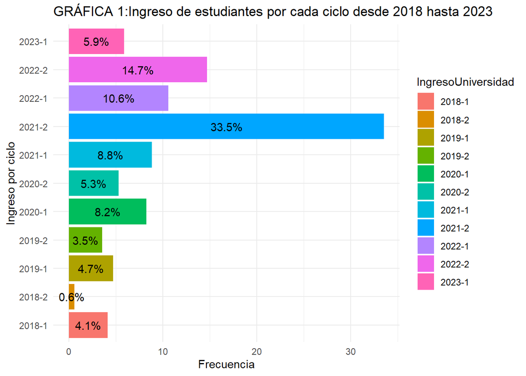

```r
val_2 <- BD %>%
  group_by(IngresoUniversidad) %>%
  count() %>%
  ungroup() %>%
  mutate(val_2 = `n` / sum(`n`) * 100)

ggplot(val_2, aes(x = IngresoUniversidad, y = val_2, fill = IngresoUniversidad)) +
  geom_bar(stat = "identity") +
  geom_text(aes(label = paste0(round(val_2, 1), "%")),
            position = position_stack(vjust = 0.5), color = "black") +
  coord_flip() +
  theme_minimal() +
  labs(x = "Ingreso por ciclo", y = "Frecuencia", title = "GRÁFICA 1:Ingreso de estudiantes por cada ciclo desde 2018 hasta 2023")
```

### 4.1.2 Escala económica:

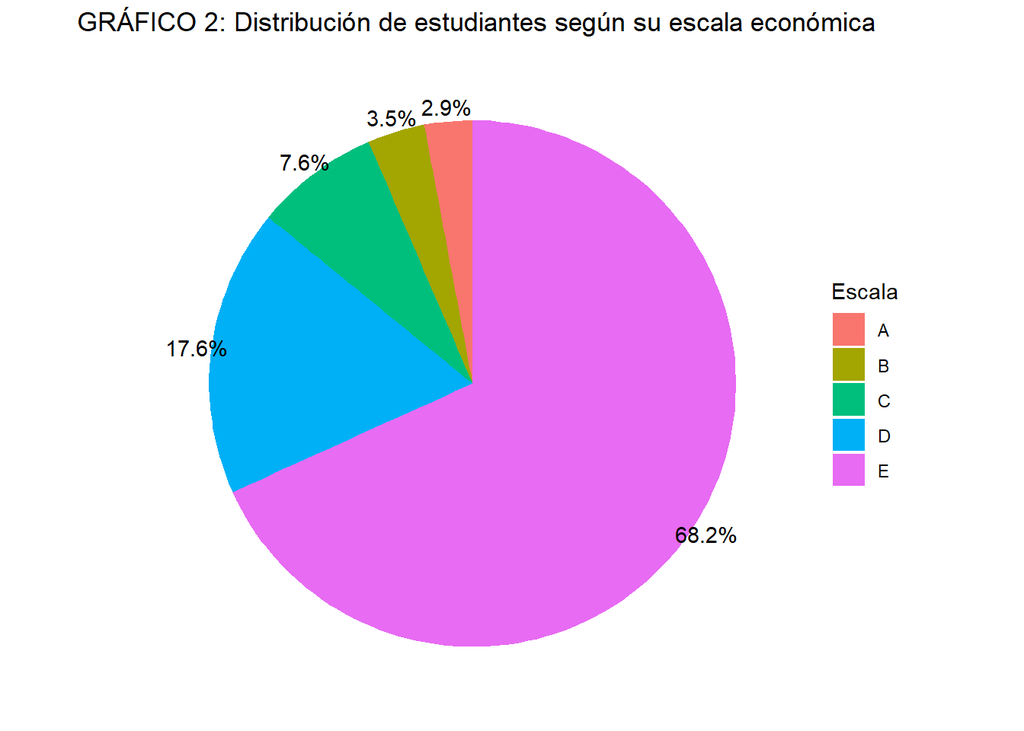

```r
proporcion <- BD2 %>%
  count(Escala) %>%
  mutate(proporcion = n / sum(n) * 100)

ggplot(proporcion, aes(x =0.90, y = proporcion, fill = Escala)) +
  geom_bar(stat = "identity") +
  coord_polar(theta = "y") +
  theme_void() +
  labs(x = NULL,
       y = NULL,
       title = " GRÁFICO 2: Distribución de estudiantes según su escala económica") +
  geom_text(aes(x = 1.4, label = paste0(round(proporcion, 1), "%")),
            position = position_stack(vjust = 0.5)) +
  theme(plot.title = element_text(hjust = 0.5),
        legend.position = "right")
```

La mayoría de los estudiantes se encuentran en la categoría “Escala E”, lo que indica que tienen menos recursos económicos. Por otro lado, un porcentaje muy bajo de estudiantes se encuentra en la categoría “Escala A” y “Escala B”, son quienes tienen mayores recursos económicos independientemente de si estudian y trabajan al mismo tiempo. Esto puede tener implicaciones en aspectos como la capacidad de afrontar gastos, acceder a ciertos servicios o enfrentar desafíos financieros durante su vida universitaria.

### 4.1.3 Presupuesto semanal según la escala de pago

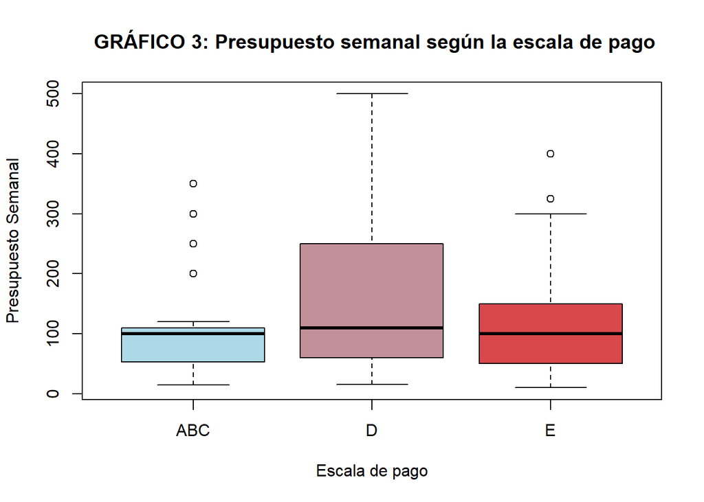

```r
boxplot(BD4$PresupuestoS ~ BD4$Escala , ylab = "Presupuesto Semanal", xlab = "Escala de pago", col=colorRampPalette(c(rgb(0.68, 0.85, 0.9),'red2'))(4),main=" GRÁFICO 3: Presupuesto semanal según la escala de pago")
```

```r
by(BD4$PresupuestoS,BD4$Escala,median)
```

```
## BD4$Escala: ABC
## [1] 100
## ------------------------------------------------------------
## BD4$Escala: D
## [1] 110
## ------------------------------------------------------------
## BD4$Escala: E
## [1] 100
```